# work_2 作業報告

# 7 第六題：請以“bon”方法進行主效果(“action 因子”)事後檢定完成分群並說明其意義

```r
TwoBetweenData.posthoc <- emmeans(TwoBetweenData.aov, ~ action)
```

```
## NOTE: Results may be misleading due to involvement in interactions
```

```r
as.data.frame(pairs(TwoBetweenData.posthoc, adjust = "bon")) %>%
  kable(align = "l", digits = 3, row.names = FALSE,
        caption = "Post-hoc Pairwise Comparisons for Action (Bonferroni)") %>%
  kable_styling(bootstrap_options = c("bordered", "responsive", "striped"), full_width = FALSE)
```

Post-hoc Pairwise Comparisons for Action (Bonferroni)

| contrast | estimate | SE | df | t.ratio | p.value |
| --- | --- | --- | --- | --- | --- |
| basic - grip | -0.609 | 0.052 | 16 | -11.657 | 0 |

> 使用 Bonferroni 方法進行動作 (action) 主效果的事後檢定顯示，basic 與 grip 兩種動作在 EEG 上有顯著差異 (basic – grip = -0.609, SE = 0.0523, t(16) = -11.657, p < .0001)。此結果表示 grip 動作的 EEG 明顯高於 basic 動作，且差異高度顯著。

# 8 第七題：請以“ bon”方法討論在性別在不同動作(靜止、抓握) 的情況下事後檢定討論

```r
TwoBetweenData.posthoc <- emmeans(TwoBetweenData.aov, ~ Sex | action)
as.data.frame(pairs(TwoBetweenData.posthoc, adjust = "bon")) %>%
  kable(align = "l", digits = 3, row.names = FALSE,
        caption = "Post-hoc Pairwise Comparisons for Sex within Action (Bonferroni)") %>%
  kable_styling(bootstrap_options = c("bordered", "responsive", "striped"), full_width = FALSE)
```

Post-hoc Pairwise Comparisons for Sex within Action (Bonferroni)

| contrast | action | estimate | SE | df | t.ratio | p.value |
| --- | --- | --- | --- | --- | --- | --- |
| F - M | basic | -0.021 | 0.074 | 16 | -0.284 | 0.78 |
| F - M | grip | -0.037 | 0.074 | 16 | -0.506 | 0.62 |

> 使用 Bonferroni 方法分別在不同動作條件下比較性別差異，結果顯示： - **basic 動作**下，男女 EEG 差異不顯著 (F–M = -0.021, SE = 0.0739, t(16) = -0.284, p = 0.780)。 - **grip 動作**下，男女 EEG 差異同樣不顯著 (F–M = -0.037, SE = 0.0739, t(16) = -0.506, p = 0.619)。 這表示無論在靜止 (basic) 或抓握 (grip) 條件下，性別對 EEG 皆沒有顯著影響，與先前 ANOVA 的結果一致。

# 9 第八題：請以“bon”方法討論在不同動作(靜止、抓握)在性別的情況下事後檢定討論

```r
TwoBetweenData.posthoc <- emmeans(TwoBetweenData.aov, ~ action | Sex)
as.data.frame(pairs(TwoBetweenData.posthoc, adjust = "bon")) %>%
  kable(align = "l", digits = 3, row.names = FALSE,
        caption = "Post-hoc Pairwise Comparisons for Action within Sex (Bonferroni)") %>%
  kable_styling(bootstrap_options = c("bordered", "responsive", "striped"), full_width = FALSE)
```

Post-hoc Pairwise Comparisons for Action within Sex (Bonferroni)

| contrast | Sex | estimate | SE | df | t.ratio | p.value |
| --- | --- | --- | --- | --- | --- | --- |
| basic - grip | F | -0.601 | 0.081 | 16 | -7.423 | 0 |
| basic - grip | M | -0.618 | 0.066 | 16 | -9.340 | 0 |

> 使用 Bonferroni 方法分別在不同性別下比較動作 (basic vs. grip) 的差異，結果顯示： * **女性 (F)**：grip 動作的 EEG 顯著高於 basic 動作，差異達顯著 (basic – grip = -0.601, SE = 0.0810, t(16) = -7.423, p < .0001)。 * **男性 (M)**：同樣地，grip 動作的 EEG 亦顯著高於 basic 動作 (basic – grip = -0.618, SE = 0.0661, t(16) = -9.340, p < .0001)。 此結果顯示，無論性別，grip 動作相較於 basic 動作都能顯著提升 EEG 值，與 ANOVA 主效果結果一致。

# 10 第九題：繪出“action 因子”與“sex 性別因子”長條圖

```r
summary_data <- dat_long %>%
  group_by(action, Sex) %>%
  summarise(
    mean_EEG = mean(EEG),
    se_EEG = sd(EEG) / sqrt(n())
  )
```

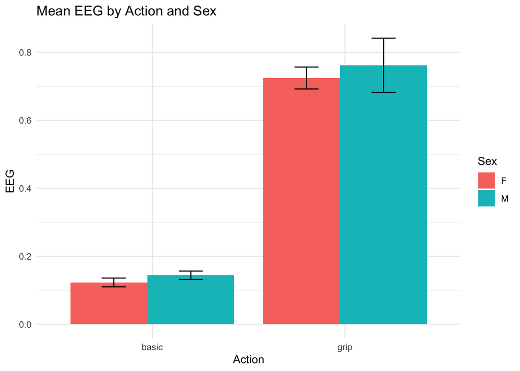

```r
ggplot(summary_data, aes(x = action, y = mean_EEG, fill = Sex)) +
  geom_bar(stat = "identity", position = position_dodge(width = 0.8)) +
  geom_errorbar(aes(ymin = mean_EEG - se_EEG, ymax = mean_EEG + se_EEG),
                position = position_dodge(width = 0.8), width = 0.25) +
  labs(title = "Mean EEG by Action and Sex",
       x = "Action",
       y = "EEG") +
  theme_minimal()
```

> 顯示不同動作（basic 與 grip）以及性別（F 與 M）在 EEG 值上的平均差異。由圖可見，在 basic 動作下，男女的 EEG 值皆偏低（約 0.1–0.15），且差異不大；然而在 grip 動作下，EEG 值明顯上升，女性約為 0.7，男性約為 0.75，整體皆高於 basic 動作。誤差線顯示數據的變異程度，男性在 grip 動作下的變異稍大於女性。整體而言，動作型態對 EEG 的影響明顯大於性別。

# 11 第十題：繪出“action 因子”與“sex 因子”之二階線圖(X 軸為 action 因子)

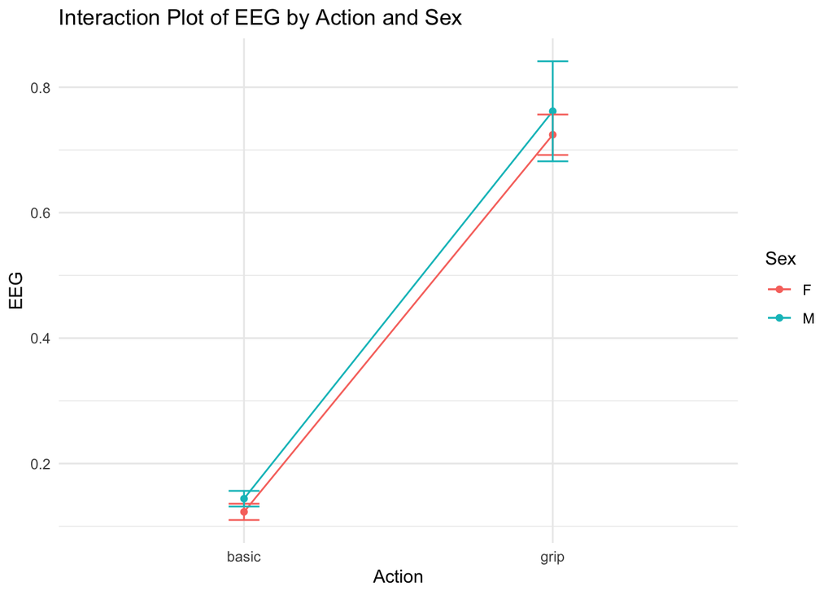

```r
ggplot(summary_data, aes(x = action, y = mean_EEG, color = Sex, group = Sex)) +
  geom_line() +
  geom_point() +
  geom_errorbar(aes(ymin = mean_EEG - se_EEG, ymax = mean_EEG + se_EEG), width = 0.1) +
  labs(title = "Interaction Plot of EEG by Action and Sex",
       x = "Action",
       y = "EEG") +
  theme_minimal()
```

> EEG 在不同動作（basic 與 grip）以及性別（F 與 M）下的交互作用圖。由圖可見，不論男女，EEG 值在 basic 動作下皆較低（約 0.1–0.15），在 grip 動作下明顯上升（約 0.7–0.8）。雖然男性在 grip 動作下的平均 EEG 稍高於女性，但兩者的趨勢幾乎平行，顯示性別對 EEG 的影響相對較小，而動作型態對 EEG 的影響更為顯著。誤差線則顯示，grip 動作下的變異性大於 basic 動作。

# 12 第十一題：繪出“action 因子”與“sex 因子”之二階線圖(X 軸為 sex 因子)

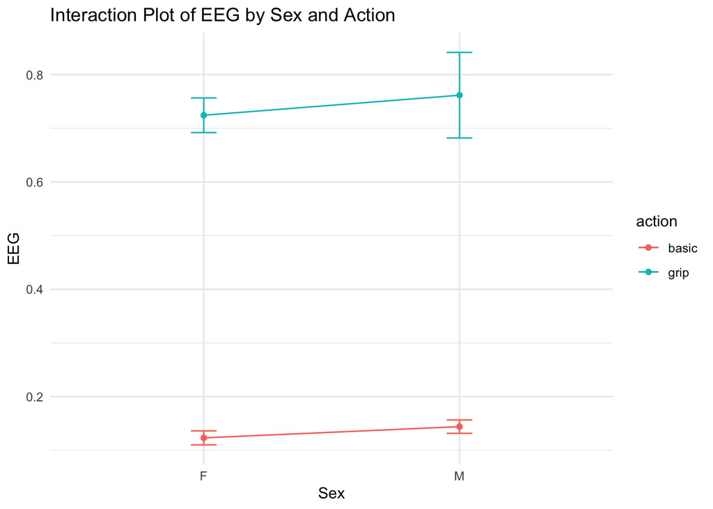

```r
ggplot(summary_data, aes(x = Sex, y = mean_EEG, color = action, group = action)) +
  geom_line() +
  geom_point() +
  geom_errorbar(aes(ymin = mean_EEG - se_EEG, ymax = mean_EEG + se_EEG), width = 0.1) +
  labs(title = "Interaction Plot of EEG by Sex and Action",
       x = "Sex",
       y = "EEG") +
  theme_minimal()
```

> 顯示不同性別（F 與 M）在兩種動作（basic 與 grip）下的 EEG 平均值變化。結果顯示，不論性別，basic 動作的 EEG 值皆偏低（約 0.1–0.15），而 grip 動作的 EEG 值顯著提高（約 0.7–0.8）。在相同動作下，男性的 EEG 平均值略高於女性，但差異幅度不大。誤差線顯示 grip 動作下的數據變異性較大，basic 動作下則相對穩定。整體而言，動作型態對 EEG 的影響遠大於性別差異。